# Data Wrangling 2

Data Tidying

Autor:in

Zugehörigkeit

Daniela Palleschi

Humboldt-Universität zu Berlin

Veröffentlichungsdatum

13. Dezember 2023

# Lernziele

Heute werden wir lernen…

- über breite versus lange Daten
- wie man breite Daten länger macht
- wie man lange Daten breiter macht

## Ressourcen

Die vorgeschlagenen Ressourcen für dieses Thema sind

- [Kapitel 6 (Data Tidying)](https://r4ds.hadley.nz/data-tidy) in Wickham et al. (2023)
- [Kapitel 8 (Data Tidying)](https://psyteachr.github.io/ads-v2/08-tidy.html) in Nordmann & DeBruine (2022)

# 1 Einrichtung

## 1.1 Pakete

```r
pacman::p_load(tidyverse,
               here,
               janitor)
```

## 1.2 Daten

- Wir verwenden den Datensatz `languageR_english.csv` (im Ordner `daten`)

```r
df_eng <- read_csv(here("daten", "languageR_english.csv")) |>
  clean_names() |>
  arrange(word) |>
  rename(
    rt_lexdec = r_tlexdec,
    rt_naming = r_tnaming
  ) |>
  select(age_subject, word, word_category, rt_lexdec, rt_naming)
```

**1**

Bereinigen (d.h. *tidy*) von Variablennamen (von `janitor`)

**2**

Zeilen nach `wort` in ansteigender Reihenfolge anordnen (A-Z)

**3**

Variablen umbenennen…

**4**

`r_tlexdec` in `rt_lexdec` umbenennen

**5**

**6**

nur die genannten Spalten behalten

# 2 ‘Tidy’ Arbeitsablauf

- Abbildung 1 zeigt einen Überblick über den typischen Data-Science-Prozess
  - Wir importieren unsere Daten, bereinigen sie und durchlaufen dann einen Zyklus aus Umwandlung, Visualisierung und Modellierung, bevor wir schließlich unsere Ergebnisse kommunizieren.

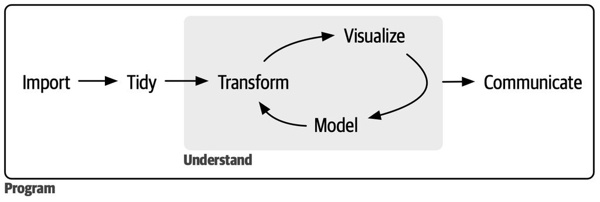

Abbildung 1: [Image source:](https://r4ds.hadley.nz/intro.html) Wickham et al. (2023) (all rights reserved)

- Bisher haben wir gelernt, wie man
  - unsere Daten importieren (`readr::read_csv`)
  - Daten transformieren (Paket `dplyr`)
  - Daten zu visualisieren (Paket `ggplot`)
  - unsere Ergebnisse mit dynamischen Berichten zu kommunizieren (Quarto)
- aber wir haben bis jetzt nur aufgeräumte Daten gesehen
  - daher mussten wir den Schritt des “tidy” (Paket `tidyr`) noch nicht durchführen

# 3 ‘Tidy’ Daten

- dieselben Daten können auf verschiedene Weise dargestellt werden
- Wir werden uns 3 Tabellen ansehen, die genau dieselben Daten in verschiedenen Formaten darstellen
- Die Tabellen zeigen die gleichen Werte von vier Variablen:
  - Land (`country`)
  - Jahr (`year`)
  - Bevölkerung (`population`)
  - Anzahl der Tuberkulosefälle (`cases`)
- Jeder Datensatz ordnet die Werte anders an
- überlegen Sie, welche Tabelle für Sie am einfachsten zu lesen ist

Tabelle 1: Tabelle 1

| country | year | cases | population |
| --- | --- | --- | --- |
| Afghanistan | 1999 | 745 | 19987071 |
| Afghanistan | 2000 | 2666 | 20595360 |
| Brazil | 1999 | 37737 | 172006362 |
| Brazil | 2000 | 80488 | 174504898 |
| China | 1999 | 212258 | 1272915272 |
| China | 2000 | 213766 | 1280428583 |

Tabelle 2: Tabelle 2

| country | year | type | count |
| --- | --- | --- | --- |
| Afghanistan | 1999 | cases | 745 |
| Afghanistan | 1999 | population | 19987071 |
| Afghanistan | 2000 | cases | 2666 |
| Afghanistan | 2000 | population | 20595360 |
| Brazil | 1999 | cases | 37737 |
| Brazil | 1999 | population | 172006362 |
| Brazil | 2000 | cases | 80488 |
| Brazil | 2000 | population | 174504898 |
| China | 1999 | cases | 212258 |
| China | 1999 | population | 1272915272 |
| China | 2000 | cases | 213766 |
| China | 2000 | population | 1280428583 |

Tabelle 3: Tabelle 3

| country | year | rate |
| --- | --- | --- |
| Afghanistan | 1999 | 745/19987071 |
| Afghanistan | 2000 | 2666/20595360 |
| Brazil | 1999 | 37737/172006362 |
| Brazil | 2000 | 80488/174504898 |
| China | 1999 | 212258/1272915272 |
| China | 2000 | 213766/1280428583 |

## 3.1 Regeln für ‘tidy’ Daten

- Wahrscheinlich ist Tabelle 1 für Sie am einfachsten zu lesen
  - sie folgt den drei Regeln für aufgeräumte Daten (visualisiert in Abbildung 2):
1. Jede Variable ist eine Spalte, jede Spalte ist eine Variable
2. Jede Beobachtung ist eine Zeile, jede Zeile ist eine Beobachtung
3. Jeder Wert ist eine Zelle, jede Zelle ist ein Einzelwert

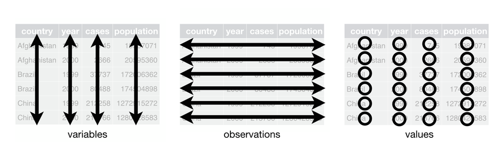

Abbildung 2: [Image source:](https://r4ds.hadley.nz/data-tidy.html) Wickham et al. (2023) (all rights reserved)

## 3.2 Warum ‘tidy’ Daten?

> “**Glückliche Familien** sind alle gleich; jede **unglückliche Familie** ist auf ihre eigene Art unglücklich.”

> — Leo Tolstoy

> “**‘Tidy’ Datensätze** sind alle gleich, aber jeder **‘untidy’ Datensatz** ist auf seine eigene Weise unordentlich.”

> — Hadley Wickham

Die Arbeit mit aufgeräumten Daten hat zwei wesentliche Vorteile:

1. Die Arbeit mit einer konsistenten Datenstruktur ermöglicht es uns, Konventionen zu übernehmen.
   - Aufgeräumte Daten sind die allgemein vereinbarte Datenstruktur
   - Konventionen/Werkzeuge basieren auf der Annahme dieser Struktur
2. Die vektorisierte Natur von R kann glänzen
   - die meisten eingebauten R-Funktionen arbeiten mit *Vektorwerten* (und Spalten sind im Wesentlichen Vektoren)
   - Alle Pakete im `tidyverse` sind darauf ausgelegt, mit aufgeräumten Daten zu arbeiten (z.B. `ggplot2` und `dplyr`)

# 4 Daten bereinigen (tidying)

- Umwandlung breiter Daten in lange Daten und langer Daten in breite Daten (neben anderen Schritten)
  - Ergebnis: aufgeräumte Daten (normalerweise)

## 4.1 ‘Tidying’ Daten mit dem `tidyverse`

- Das Paket `tidyr` (aus `tidyverse`) hat zwei nützliche Funktionen zum Transponieren unserer Daten:
  - `pivot_longer()`: macht breite Daten länger
  - `pivot_wider()`: lange Daten breiter machen

[figure not shown]

Abbildung 3: die berühmteste Verwendung des Wortes Pivot (zumindest für Millenials) ([Friends](https://www.youtube.com/watch?v=8w3wmQAMoxQ))

## 4.2 Breite versus lange Daten

- Wir müssen oft zwischen breiten und langen Datenformaten konvertieren, um verschiedene Arten von Zusammenfassungen oder Visualisierungen zu erstellen
- breite Daten: alle Beobachtungen zu einer Sache befinden sich in einer einzigen Zeile
  - ist *normalerweise* nicht aufgeräumt
- lange Daten: jede Beobachtung befindet sich in einer separaten Zeile
  - ist *normalerweise* aufgeräumt
- Beginnen wir mit dem typischsten Fall: Umwandlung breiter Daten in lange Daten

# 5 `pivot_longer()`

- im Datensatz `languageR_english.csv` (`df_eng`)
  - haben wir 4568 Beobachtungen (Zeilen)
  - Wir haben 5 Variablen (Spalten)
  - die Spalte `age_subject` gibt an, ob eine Beobachtung von einem Teilnehmer der Altersgruppe `old` oder `young` stammt
  - die Spalten `word` und `word_category` beschreiben Eigenschaften des Stimulus für eine bestimmte Beobachtung (d. h. das Wort)
  - die Spalte `rt_lexdec` enthält die Reaktionszeit für eine lexikalische Entscheidungsaufgabe
  - die Spalte `rt_naming` enthält die Antwortzeit für eine Wortbenennungsaufgabe

Tabelle 4: df_eng

| age_subject | word | word_category | rt_lexdec | rt_naming |
| --- | --- | --- | --- | --- |
| young | ace | N | 623.61 | 456.3 |
| old | ace | N | 775.67 | 607.8 |
| young | act | V | 617.10 | 445.8 |
| old | act | V | 715.52 | 639.7 |
| young | add | V | 575.70 | 467.8 |
| old | add | V | 742.19 | 605.4 |

- Sind diese Daten in Tabelle 4 aufgeräumt?
- Sind diese Daten zu breit oder zu lang?
- Wie können wir diese Daten länger machen?

## 5.1 Our goal

- wir wollen Abbildung 4 produzieren

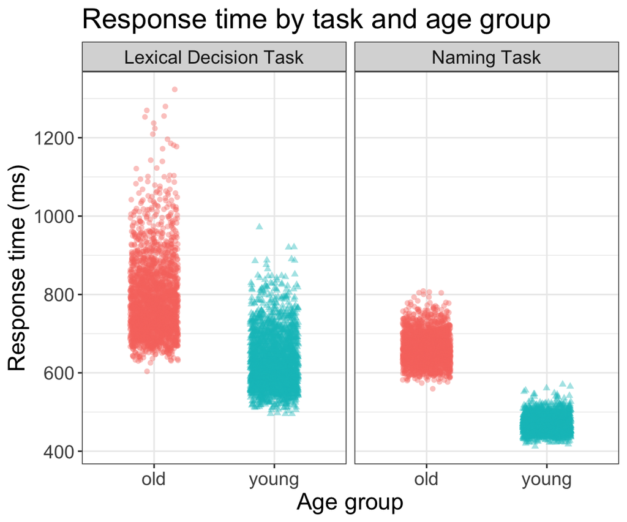

Abbildung 4: Our plot to be reproduced

- die beiden kontinuierlichen Variablen `rt_lexdec` und `rt_naming` erscheinen in Facetten
  - `facet_wrap()` nimmt eine *kategorische* Variable als Argument und erzeugt eine Facette für jede Kategorie
- wir brauchen also eine kategorische Variable, die die Ebenen `lexdec` und `naming` enthält
  - und eine *kontinuierliche* Variable, die die entsprechende Antwortzeit enthält

## 5.2 `pivot_longer()`

- Die Funktion `pivot_longer()` (von `tidyr`) konvertiert eine breite Datentabelle in ein längeres Format
  - wandelt die Namen der angegebenen Spalten in die Werte einer neuen kategorischen Spalte um
  - und kombiniert die Werte dieser Spalten in einer neuen Spalte

```r
df_eng_long <-
  df_eng %>%
  pivot_longer(
    cols = starts_with("rt_"),
    names_to = "response",
    values_to = "time"
  )
```

**1**

Erstellen Sie ein neues Objekt namens `df_eng_long`, das…

**2**

`df_eng`, und dann

**3**

mache es länger

**4**

indem du Spalten (`col =`) nimmst, die mit `rt_` beginnen

**5**

und eine Variable namens `response` erstellen, die die Namen aus `cols` enthält (`names_to =`)

**6**

und eine Variable namens `time` erstellen, die die Werte aus `cols` enthält (`values_to =`)

```r
df_eng_long |> head()
```

```
# A tibble: 6 × 5
  age_subject word  word_category response   time
  <chr>       <chr> <chr>         <chr>     <dbl>
1 young       ace   N             rt_lexdec  624.
2 young       ace   N             rt_naming  456.
3 old         ace   N             rt_lexdec  776.
4 old         ace   N             rt_naming  608.
5 young       act   V             rt_lexdec  617.
6 young       act   V             rt_naming  446.
```

- Vergleichen wir die Beobachtungen für die Wörter `ace` und `act` in
  - `df_eng` (Tabelle 5)
  - `df_eng_longer` (Tabelle 6)

Tabelle 5: `df_eng`

| age_subject | word | rt_lexdec | rt_naming |
| --- | --- | --- | --- |
| young | ace | 623.61 | 456.3 |
| old | ace | 775.67 | 607.8 |
| young | act | 617.10 | 445.8 |
| old | act | 715.52 | 639.7 |

Tabelle 6: `df_eng |> pivot_longer(...)`

| age_subject | word | response | time |
| --- | --- | --- | --- |
| young | ace | rt_lexdec | 623.61 |
| young | ace | rt_naming | 456.30 |
| old | ace | rt_lexdec | 775.67 |
| old | ace | rt_naming | 607.80 |
| young | act | rt_lexdec | 617.10 |
| young | act | rt_naming | 445.80 |
| old | act | rt_lexdec | 715.52 |
| old | act | rt_naming | 639.70 |

- die beiden Tabellen enthalten genau die gleichen Informationen
  - 8 Werte für die Antwortzeit:
    - 4 für `rt_lexdec`
    - 4 für `rt_naming`
- Dies ist eine wichtige Erkenntnis: Wir haben keine Daten oder Beobachtungswerte geändert, sondern lediglich die Organisation der Datenpunkte neu strukturiert.

### 5.2.1 Plotten unserer ‘tidy’ Daten

- Versuchen wir nun, unser Diagramm zu erstellen:
  - `age_subject` auf der x-Achse
  - `time` auf der y-Achse
  - Kategorien `response` in Facetten

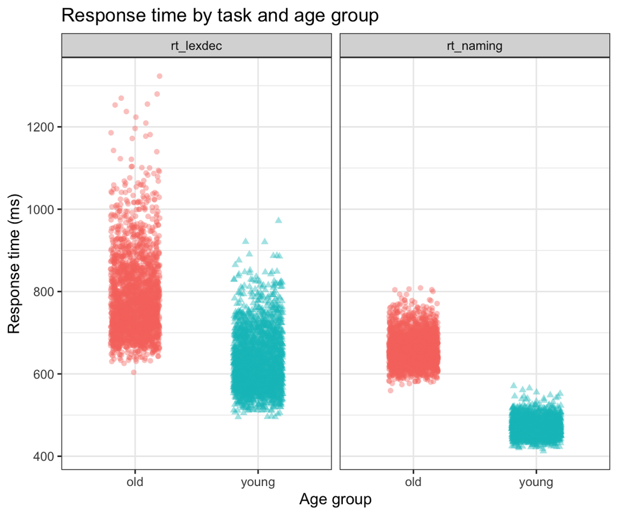

Abbildung 5: Response times per age group for the lexical decision task vs. naming task

**Aufgabe 1: Tidy data**

**Beispiel 1**

Abbildung 5 neu erstellen.

# 6 `pivot_wider()`

- Es kommt häufiger vor, dass man seine Daten verlängern will (man nimmt Spalten und macht aus deren Werten neue Zeilen)
  - aber manchmal möchte man seine Daten auch verbreitern (man nimmt Zeilen und verwandelt ihre Werte in neue Spalten)
- Die `tidyr`-Funktion `pivot_wider()` macht Datensätze *breiter*, indem sie Spalten vergrößert und Zeilen reduziert.
  - Dies ist hilfreich, wenn eine Beobachtung über mehrere Zeilen verteilt ist.
- Lassen Sie uns versuchen, `df_eng` breiter zu machen
  - Wir könnten zum Beispiel eine einzige Zeile pro *Wort* haben
    - mit einer einzigen Variablen für die Antwort des `young` Probanden und die Antwort des `old` Probanden

## 6.2

- lassen Sie uns zwei neue Variablen erstellen, die ihre Namen von `age_subject` und ihre Werte von `rt_lexdec` übernehmen

```r
df_eng_wide <-
  df_eng %>%
  select(-rt_naming) |>
  pivot_wider(
    names_from = age_subject,
    values_from = rt_lexdec,
    names_prefix = "lexdec_"
  )
```

**1**

neue Spaltennamen unter Verwendung der Werte in `age_subject` erstellen

**2**

Erstelle neue Beobachtungswerte aus `rt_lexdec`

**3**

Hinzufügen von `lexdec_` am Anfang der neuen Spaltennamen

## 6.3

Tabelle 7: `df_eng`

| age_subject | word | word_category | rt_lexdec |
| --- | --- | --- | --- |
| young | ace | N | 623.61 |
| old | ace | N | 775.67 |
| young | act | V | 617.10 |
| old | act | V | 715.52 |

Tabelle 8: `df_eng_wide`

| word | word_category | lexdec_young | lexdec_old |
| --- | --- | --- | --- |
| ace | N | 623.61 | 775.67 |
| act | V | 617.10 | 715.52 |

- Auch hier haben wir keine Daten oder Beobachtungswerte geändert, sondern lediglich die Anordnung der Datenpunkte neu strukturiert.

**Eindeutige Werte**

Tabelle 9: Wider `df_eng` data with NA’s

| word | word_category | rt_naming | lexdec_young | lexdec_old |
| --- | --- | --- | --- | --- |
| ace | N | 456.3 | 623.61 | NA |
| ace | N | 607.8 | NA | 775.67 |
| act | V | 445.8 | 617.10 | NA |
| act | V | 639.7 | NA | 715.52 |

# Lernziele 🏁

Heute haben wir gelernt…

- über breite und lange Daten ✅
- wie man breite Daten länger macht ✅
- wie man lange Daten breiter macht ✅

# 7 Hausaufgaben

Für diese Aufgaben werden wir mit dem Datensatz `df_eng` arbeiten.

1. Verwenden Sie `pivot_wider`, um mit `rt_naming` neue Variablen zu erstellen: `naming_old` und `naming_young`, die die Reaktionszeiten beim Benennen für alte bzw. junge Teilnehmer enthalten. Hinweis: Sie müssen `rt_lexdec` entfernen. Der resultierende Datenrahmen sollte 2284 Beobachtungen und 4 Variablen enthalten.
2. Erstellen Sie Abbildung 6 neu. Hinweis: Sie benötigen `pivot_wider()`.

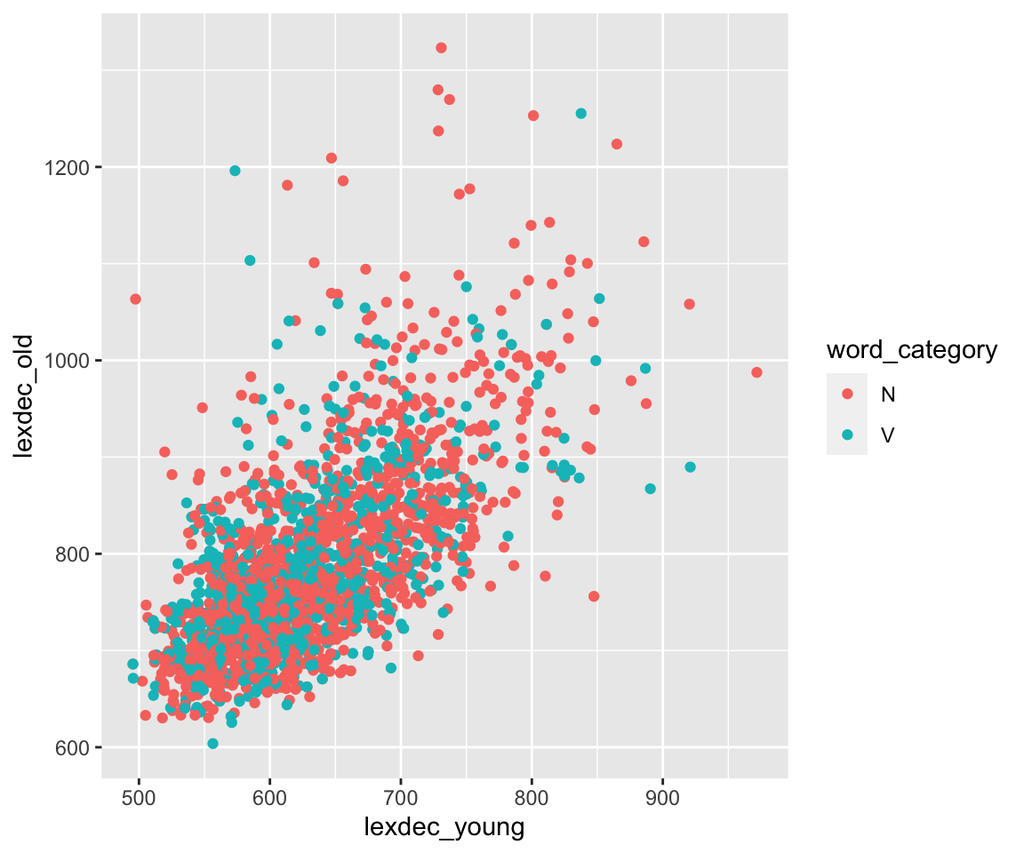

Abbildung 6: Scatterplot of lexical decision task response times per word for old versus young participants

3. Warum brauchen wir den Datensatz `df_eng_wide`, um Abbildung 6 zu erstellen? Mit anderen Worten, warum ist `df_eng_wide` die geeignete Struktur für ein solches Streudiagramm, aber nicht `df_eng_long`?
4. Verwenden Sie `df_eng_long` und die Funktion `summarise()`, die wir im letzten Abschnitt gesehen haben, um die folgende Zusammenfassung zu reproduzieren:

```
# A tibble: 2 × 3
  response   mean    sd
  <chr>     <dbl> <dbl>
1 rt_lexdec  708.  115.
2 rt_naming  566.  101.
```

Hinweis: Müssen Sie `NA` entfernen (wir haben letzen Woche gesehen, wie man das macht)?

# Session Info

Hergestellt mit R version 4.3.0 (2023-04-21) (Already Tomorrow) und RStudioversion 2023.9.0.463 (Desert Sunflower).

# Literaturverzeichnis

Nordmann, E., & DeBruine, L. (2022). *Applied Data Skills*. Zenodo. https://doi.org/10.5281/zenodo.6365078

Wickham, H., Çetinkaya-Rundel, M., & Grolemund, G. (2023). *R for Data Science* (2. Aufl.).